# More straightforward movement variable definitions

## Categorize the movement behaviors, and reduce the number of movement behaviors that we’re including

The PCA movement variables are a little hard to interpret, and I want the predictor variables to directly describe aspects of individual behavior/movement/space use.  
New proposal is to make a PCA of the strictly movement-related variables, a PC of the strictly roosting-related variables, and then use AKDE home ranges as the third variable measuring space use. Here is what this would look like:

## Movement PCA

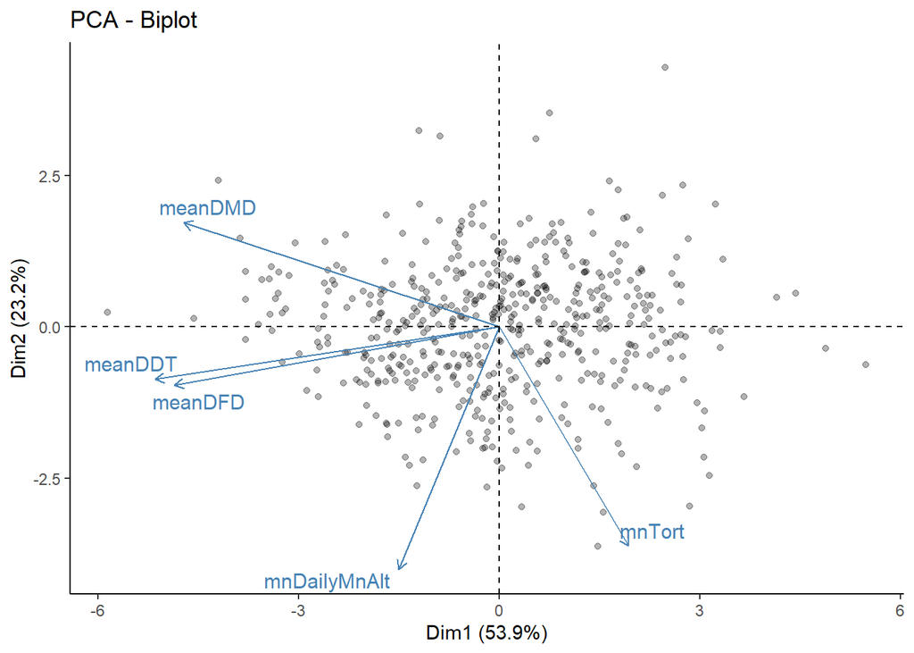

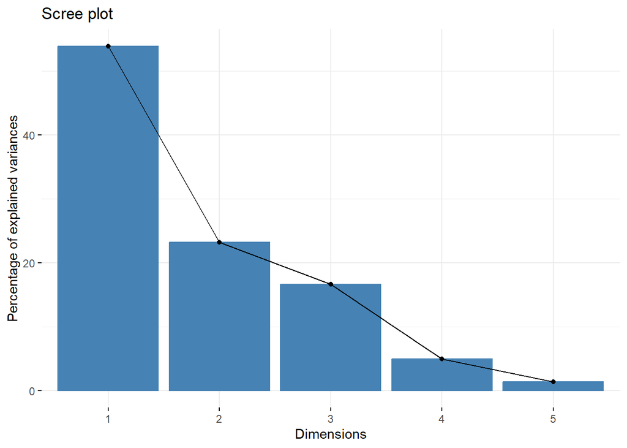

```
                PC1    PC2    PC3
mnDailyMnAlt  16.98  68.90  65.87
meanDFD       54.89  16.52 -19.37
meanDMD       53.33 -29.61 -12.45
meanDDT       58.12  14.86 -15.78
mnTort       -21.85  62.30 -69.87
```

### Interpretation

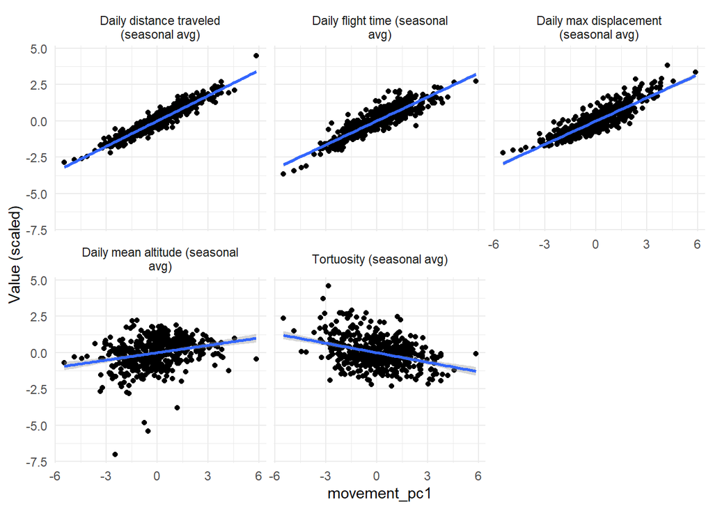

Individuals with higher movement PC1 values fly higher and farther, spend more time flying, and have straighter paths than individuals with lower movement PC1 values. Let’s call this measure just “movement”.

## Roost behavior PCA

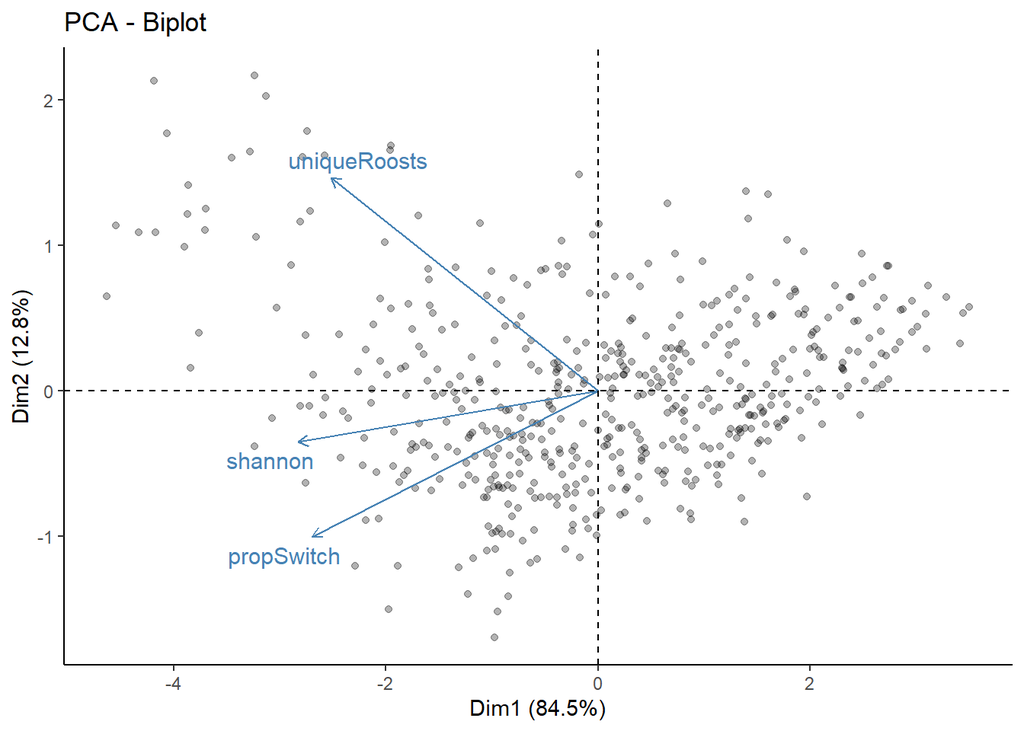

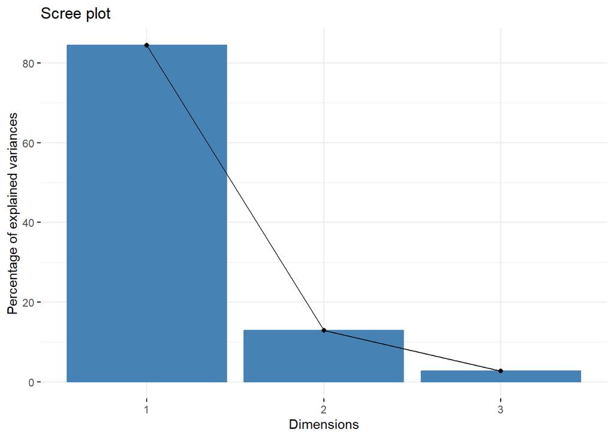

```
               PC1    PC2    PC3
propSwitch   58.03  55.30 -59.78
shannon      60.84  19.36  76.97
uniqueRoosts 54.14 -81.04 -22.41
```

### Interpretation

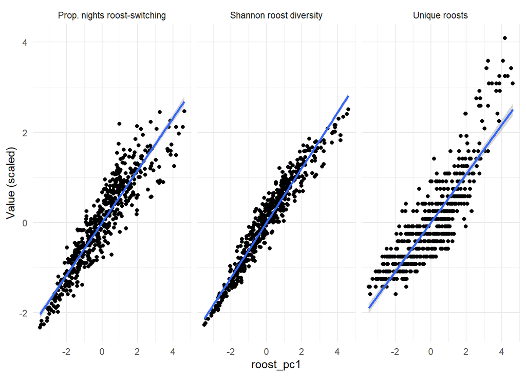

Individuals that are higher on the roost PC1 have more unique roosts, a higher roost diversity, and switch roosts more often. Let’s call this a measure of “**roost site diversification**” or something like that.

## Variable distributions

Let’s examine these predictor variables

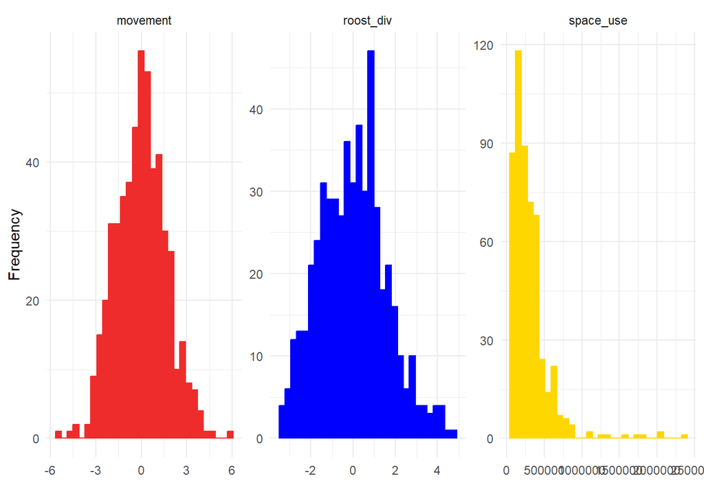

We can see here that we have another problem. Since `movement` and `roost_div` are composite variables derived from PCAs, they are pretty close to normally distributed. Meanwhile, our space use variable is very right-skewed, because it’s a measure of area.

Let’s log-tranform the space use variable to make the distributions more comparable and therefore make the modeling easier.

Re-examine the distributions of the variables after log-transforming:

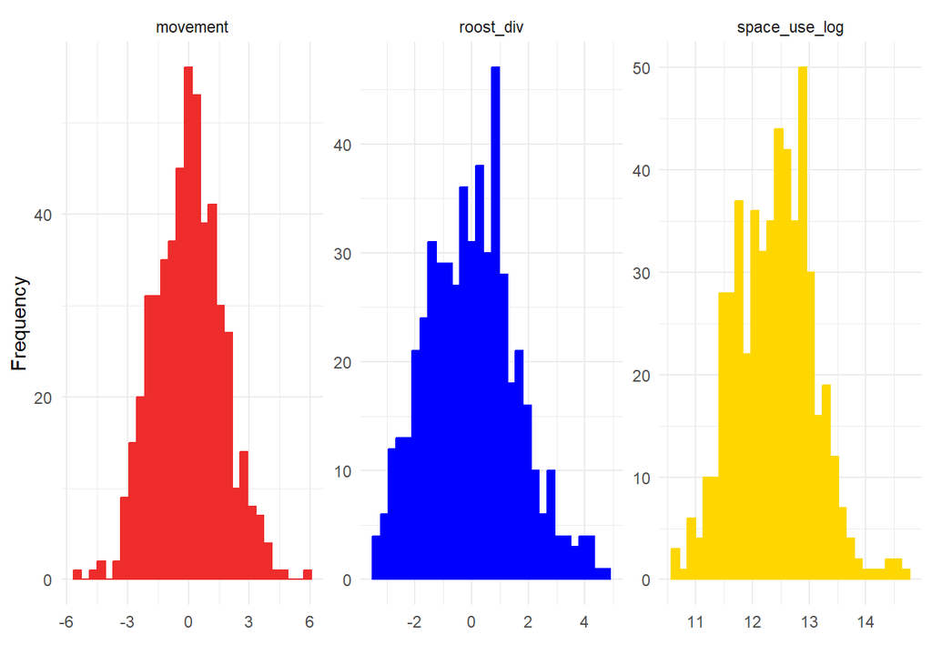

Okay that’s still not perfect, but it’s a lot better.

*Note also that this outcome may change quantitatively after we calculate the home ranges by better means (AKDE), but I don’t expect it to be qualitatively different. AKDE calculations are currently in progress.*

## Correlations

These are still three measures of movement, so I expect that they will be at least somewhat correlated. Let’s take a look!

**Movement** and **roost diversification** have a correlation of 0.52.

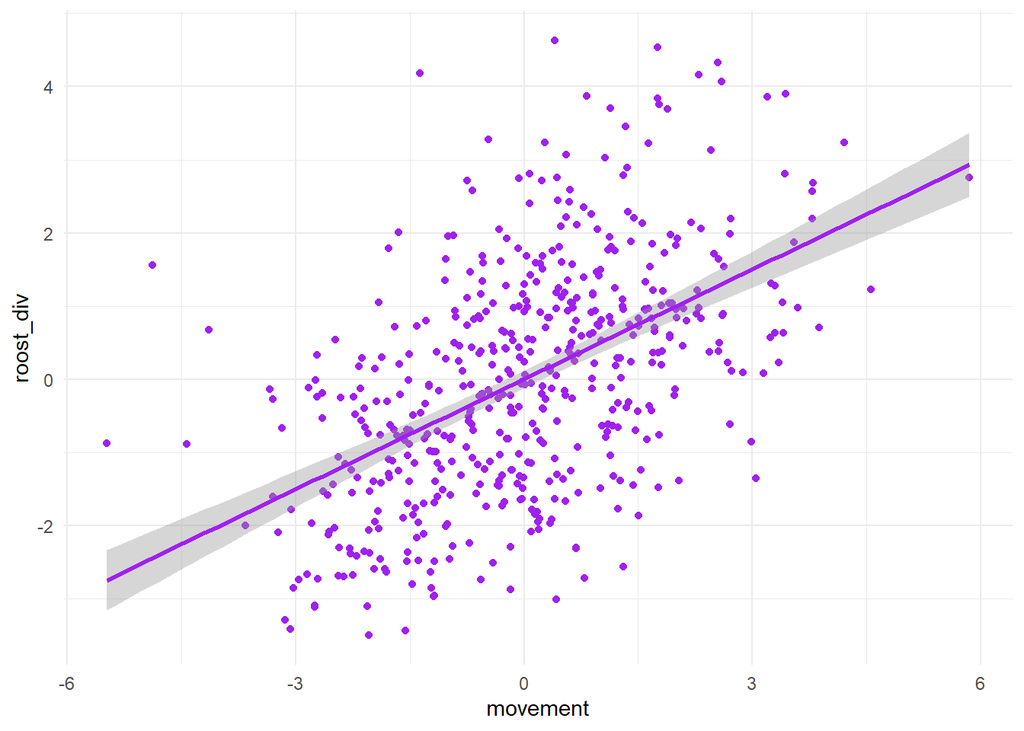

**Roost diversification** and **log-transformed home range** have a stronger correlation of 0.62.

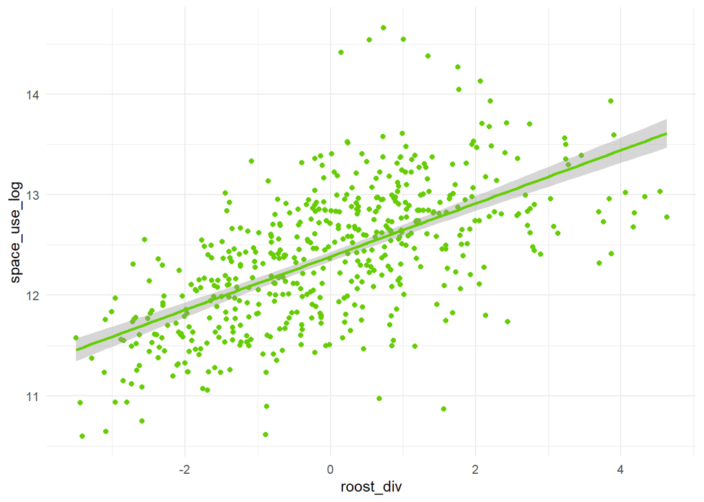

Finally, **log-transformed home range** and **movement** have a correlation of 0.49.

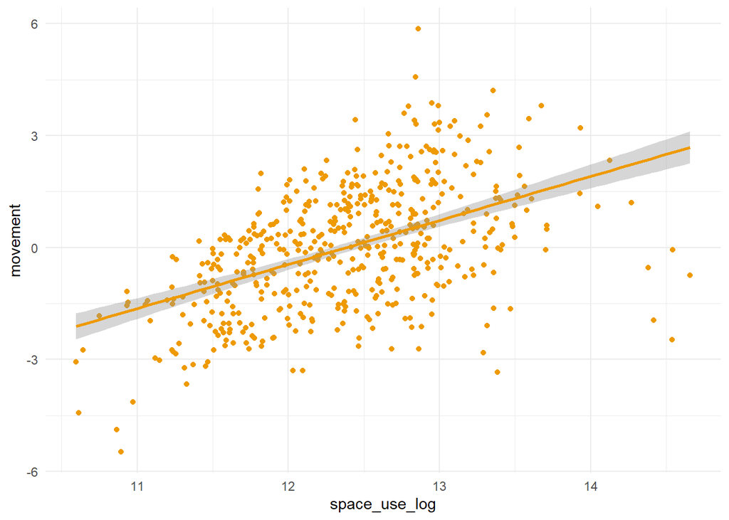

There is enough correlation here that we’re going to have to be careful, but I don’t think there’s enough that we have to not proceed. These predictors seem more biologically defensible because they are created *a priori* instead of derived from a single PCA.

## Examine effects of age and sex

Let’s see if the relationships between these variables and age are consistent with what Marta found (they should be!)

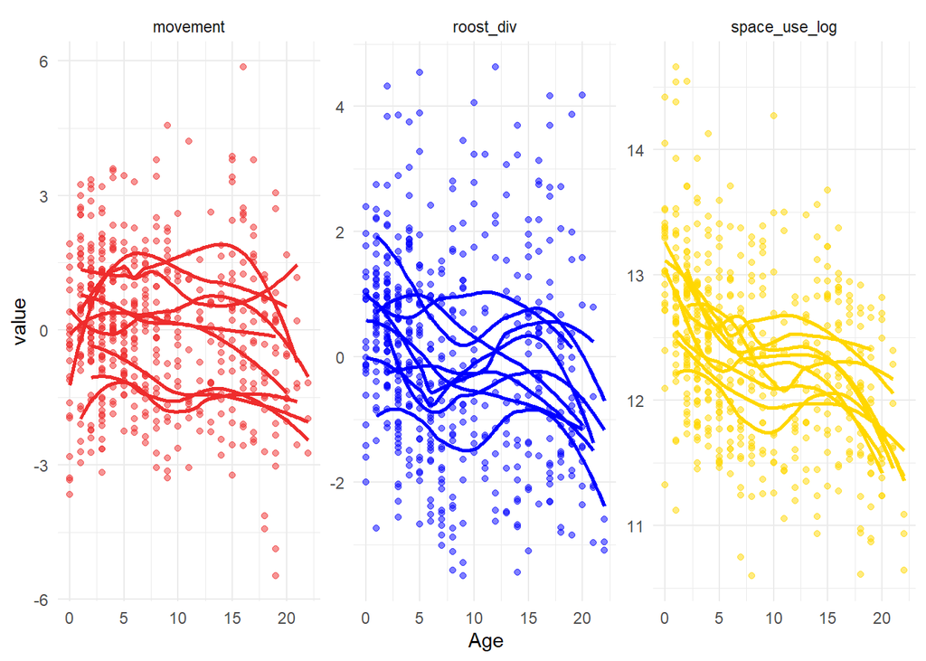

We sort of recover the same patterns as Marta, but they’re not perfectly clear-cut.

Just in case we had any doubts about vultures’ lack of sexual dimorphism…

[figure not shown]

Okay, yeah, so about those seasons:

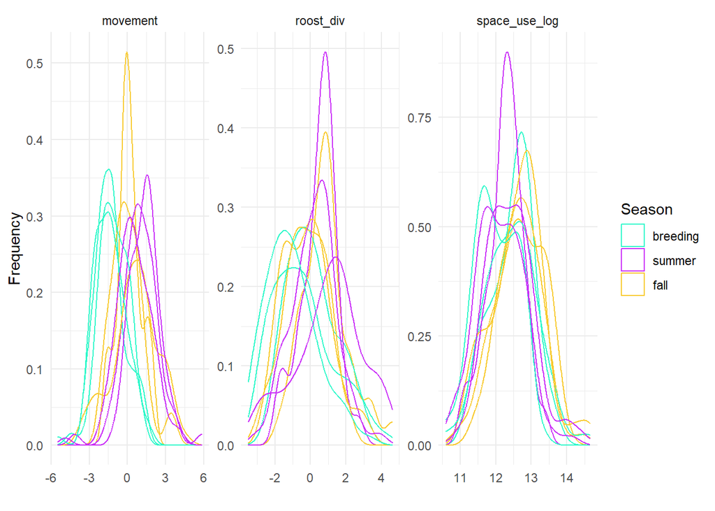

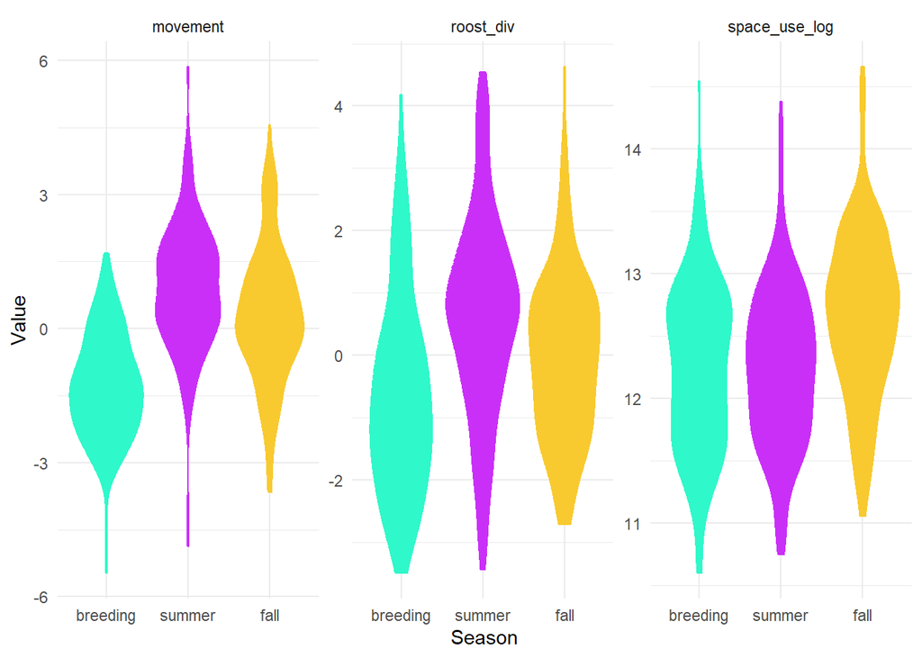

There’s not a huge amount of differentiation by season, but there’s a little bit. As expected, we do see the most movement in the summer and the least during the breeding season.

```
# A tibble: 6 x 14
  Nili_id  seasonUnique daysTracked propDaysTracked birth_year sex   space_use
  <chr>    <chr>              <dbl>           <dbl>      <dbl> <chr>     <dbl>
1 Jill     2020_fall         -1.67           -1.59        2018 m       899532.
2 abel     2020_fall         -0.317           0.827       2016 NA      246231.
3 addo     2020_fall         -0.612           0.301       2019 f       117170.
4 aliwal   2020_fall         -2.03           -2.22        2020 m       752239.
5 alyeska  2020_fall         -1.44           -1.17        2020 NA      445164.
6 anderson 2020_fall         -0.347           0.774       2001 m       229183.
# i 7 more variables: movement <dbl>, roost_div <dbl>, space_use_log <dbl>,
#   season <fct>, year <dbl>, age <dbl>, age_group <chr>
```